# Julius Rissanen

julius.rissanen@helsinki.fi

8.3.2017

Abstract

‘No Show appointments’-data provides information on people who have went to medical care and then missed or participated on the appointment. Not showing up is big problem as about 30% of people in dataset don’t show up at the appointment. Dataset is really decently sized at 300 000 patients which provides good overview of the problem without small sample size problems. Logistic regression was chosen as statistical method to provide easily understandable model for intepreting the each variable’s effect. Predictors which predicted increasing chance of missing the appointment were easily forecastable (alchoholism, smokers, saturday). Surprising predictor was before appointment sent SMS messages which didn’t seem to have effect on people showing up. Logistic regression didn’t provide good prediction accuracy in the end and thus more complex models would be needed if we want to get better at predicting who will miss their appointment.

```r
#needed libraries
library(ggplot2)
library(tidyverse)
library(reshape)
library(gridExtra)
library(stargazer)
library(magrittr)
library(boot)
```

# 1. Medical appointment show up

## 1.1 Description of the research question

My study looks to find what backgrounds in people can predict their probability of missing medical appointments.

## 1.2 Data wrangling

Data wrangling file can be found from the github page: https://github.com/JuliusRissanen/IODS-final/blob/master/data/create_noShow.R

## 1.3 Description of the data

My data is open dataset from Kaggle. It has 300 000 patients and their status if they missed or didn’t miss their medical appointment. Data can be downloaded from: https://www.kaggle.com/joniarroba/noshowappointments

```r
#load dataset
noShow <- read.csv("data/noShow.csv", row.names = 1)

#fix RegistrationDate and AppoitmentDate to 'date' variables
noShow$RegistrationDate <- as.Date(noShow$RegistrationDate)
noShow$AppoitmentDate <- as.Date(noShow$AppoitmentDate)
#Fix binaries to logical
noShow$Diabetes <- as.logical(noShow$Diabetes)
noShow$Alchoholism <- as.logical(noShow$Alchoholism)
noShow$Hypertension <- as.logical(noShow$Hypertension)
noShow$Handicap <- as.logical(noShow$Handicap)
noShow$Smokes <- as.logical(noShow$Smokes)
noShow$Scholarship <- as.logical(noShow$Scholarship)
noShow$Tuberculosis <- as.logical(noShow$Tuberculosis)
noShow$Status <- as.logical(noShow$Status)

#Check structure of the data
str(noShow)
```

```
## 'data.frame':    299988 obs. of  16 variables:
##  $ Age             : int  19 24 4 5 38 5 46 4 20 51 ...
##  $ Gender          : Factor w/ 2 levels "F","M": 2 1 1 2 2 1 1 1 1 1 ...
##  $ DayOfTheWeek    : Factor w/ 6 levels "Friday","Monday",..: 6 6 5 4 5 5 5 1 5 5 ...
##  $ Diabetes        : logi  FALSE FALSE FALSE FALSE FALSE FALSE ...
##  $ Alchoholism     : logi  FALSE FALSE FALSE FALSE FALSE FALSE ...
##  $ Hypertension    : logi  FALSE FALSE FALSE FALSE FALSE FALSE ...
##  $ Handicap        : logi  FALSE FALSE FALSE FALSE FALSE FALSE ...
##  $ Smokes          : logi  FALSE FALSE FALSE FALSE FALSE FALSE ...
##  $ Scholarship     : logi  FALSE FALSE FALSE FALSE FALSE FALSE ...
##  $ Tuberculosis    : logi  FALSE FALSE FALSE FALSE FALSE FALSE ...
##  $ Sms_Reminder    : int  0 0 0 1 1 1 1 1 0 1 ...
##  $ AwaitingTime    : int  -29 -1 -1 -15 -6 -35 -18 -14 -14 -4 ...
##  $ Status          : logi  FALSE FALSE FALSE FALSE FALSE TRUE ...
##  $ AppoitmentDate  : Date, format: "2015-01-14" "2015-08-19" ...
##  $ RegistrationDate: Date, format: "2014-12-16" "2015-08-18" ...
##  $ RegistrationHour: int  14 7 12 17 15 6 19 8 11 7 ...
```

From the structure of the data we can se that it has 16 variables and 299 988 patients. 6 patients were deleted from the original dataset because of unreasonable values in age variable (<0) also only 6 people were on registered on sunday so they are also deleted from causing problems with DayOfTheWeek variable. Date and time based variables were cleaned to have only dates or hours. Handicap and SMS_reminder variables were recoded to binaries (from 0-4 scale Handicap and 0-2 amount of SMS send)

Variables are self explanatory from their names.

Continuous ones are Age and AwaitingTime. Awaiting time calculates how many days were between their reservation and medical appoitment.

Binary ones are Diabetes, Alcholism, Hypertension, Smokes, Scholarship, Tuberculosis, handicap, SMS_reminder where 1 means person is e.g. diabetic (‘Diabetes’ variable).

## 1.4 Data exploration

First we start with basic descriptive statistics

```r
summary(noShow)
```

```
##       Age         Gender        DayOfTheWeek    Diabetes
##  Min.   :  0.00   F:200493   Friday   :52769   Mode :logical
##  1st Qu.: 19.00   M: 99495   Monday   :59297   FALSE:276598
##  Median : 38.00              Saturday : 1393   TRUE :23390
##  Mean   : 37.81              Thursday :60260   NA's :0
##  3rd Qu.: 56.00              Tuesday  :62774
##  Max.   :113.00              Wednesday:63495
##  Alchoholism     Hypertension     Handicap         Smokes
##  Mode :logical   Mode :logical   Mode :logical   Mode :logical
##  FALSE:292485    FALSE:235223    FALSE:294391    FALSE:284277
##  TRUE :7503      TRUE :64765     TRUE :5597      TRUE :15711
##  NA's :0         NA's :0         NA's :0         NA's :0
##
##
##  Scholarship     Tuberculosis     Sms_Reminder     AwaitingTime
##  Mode :logical   Mode :logical   Min.   :0.0000   Min.   :-398.00
##  FALSE:270919    FALSE:299853    1st Qu.:0.0000   1st Qu.: -20.00
##  TRUE :29069     TRUE :135       Median :1.0000   Median :  -8.00
##  NA's :0         NA's :0         Mean   :0.5715   Mean   : -13.84
##                                  3rd Qu.:1.0000   3rd Qu.:  -4.00
##                                  Max.   :1.0000   Max.   :  -1.00
##    Status        AppoitmentDate       RegistrationDate
##  Mode :logical   Min.   :2014-01-02   Min.   :2013-05-29
##  FALSE:209260    1st Qu.:2014-07-04   1st Qu.:2014-06-24
##  TRUE :90728     Median :2014-12-16   Median :2014-12-03
##  NA's :0         Mean   :2014-12-28   Mean   :2014-12-14
##                  3rd Qu.:2015-06-25   3rd Qu.:2015-06-11
##                  Max.   :2015-12-30   Max.   :2015-12-29
##  RegistrationHour
##  Min.   : 5.00
##  1st Qu.: 8.00
##  Median :11.00
##  Mean   :11.27
##  3rd Qu.:14.00
##  Max.   :22.00
```

30% of people in the dataset missed the medical appointment.

### 1.4.1 Age further exploration

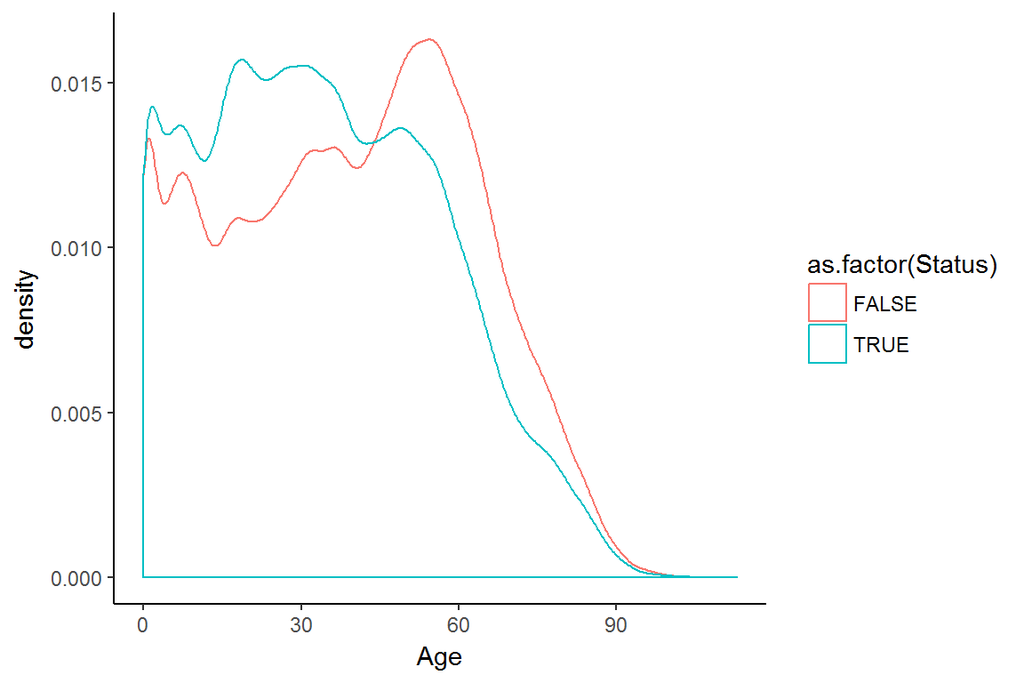

```r
ggplot(noShow, aes(Age)) + geom_density(aes(color = as.factor(Status))) + theme_classic()
```

### 1.4.2 ‘Gender’ further exploration

We will see graphically how gender affects arrival to medical appoitment.

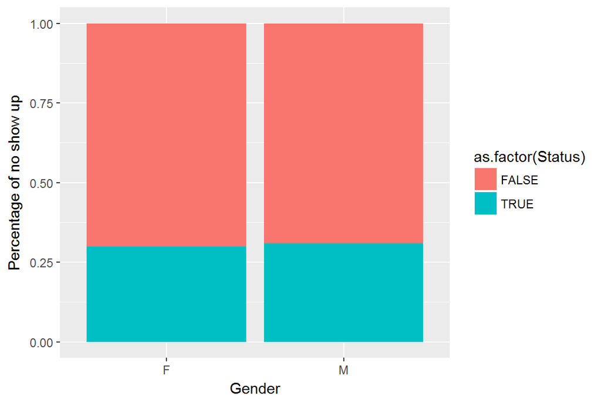

```r
ggplot(noShow, aes(x=as.factor(Gender), fill= as.factor(Status))) + geom_bar(position ='fill') + xlab("Gender") + ylab("Percentage of no show up")
```

Gender doesn’t seem to have clear difference in the affect of no show up.

### 1.4.3 SMS-reminder further exploration

We will check basic graph on SMS-remind variable if it looks to have affect on showing up.

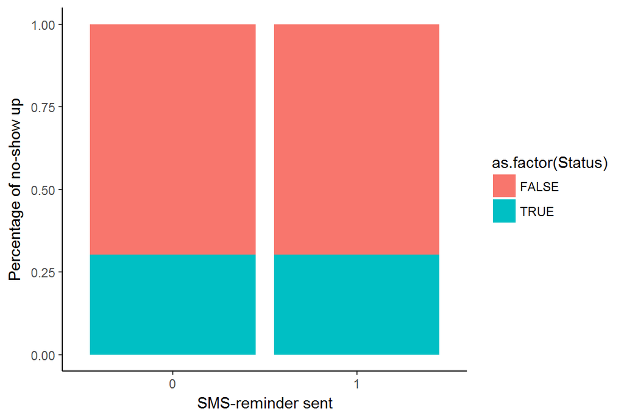

```r
ggplot(noShow, aes(x=as.factor(Sms_Reminder), fill = as.factor(Status))) + geom_bar(position = 'fill') + ylab("Percentage of no-show up") + xlab("SMS-reminder sent") + theme_classic()
```

Even closer difference.

### 1.4.4 Other binary variables

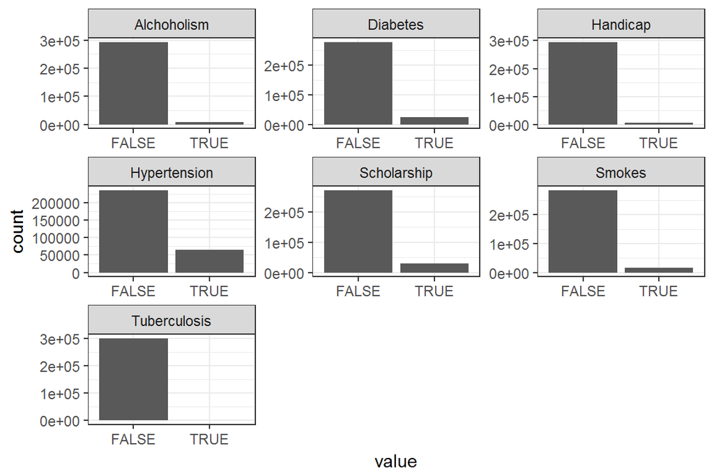

```r
keep_variables <- c("Diabetes", "Alchoholism", "Hypertension", "Handicap", "Smokes", "Scholarship", "Tuberculosis")
binaries <- select(noShow, one_of(keep_variables))
gather(binaries) %>% ggplot(aes(value), fill = Status) + facet_wrap("key", scales = "free") + geom_bar() + theme_bw()
```

And then next their distribution compared to Status

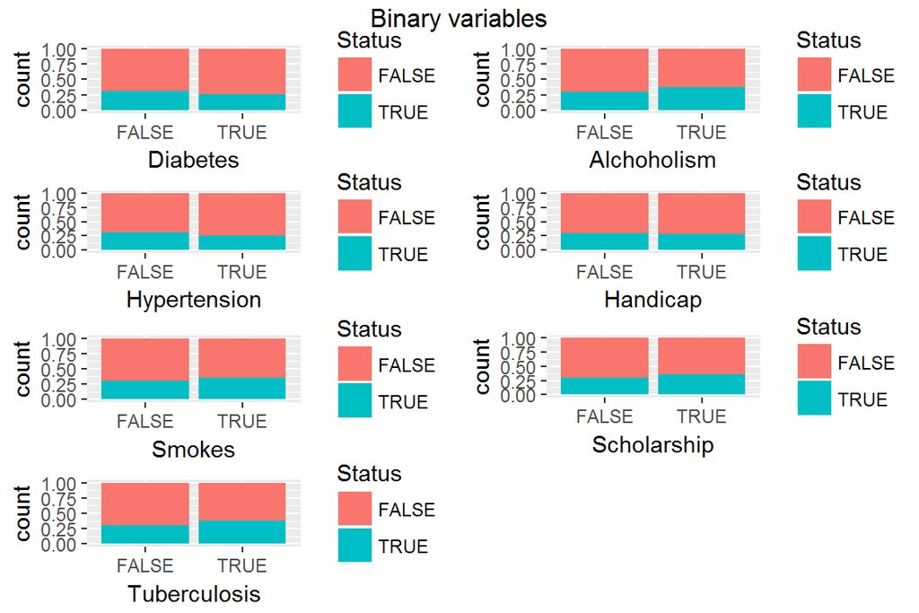

```r
Diabetes_graph <- ggplot(noShow, aes(x=Diabetes, fill=Status)) + geom_bar(position="fill")

Alchoholism_graph <- ggplot(noShow, aes(x=Alchoholism, fill=Status)) + geom_bar(position="fill")

Hypertension_graph <- ggplot(noShow, aes(x=Hypertension, fill=Status)) + geom_bar(position="fill")

Handicap_graph <- ggplot(noShow, aes(x=Handicap, fill=Status)) + geom_bar(position="fill")

Smokes_graph <- ggplot(noShow, aes(x=Smokes, fill=Status)) + geom_bar(position="fill")

Scholarship_graph <- ggplot(noShow, aes(x=Scholarship, fill=Status)) + geom_bar(position="fill")

Tuberculosis_graph <- ggplot(noShow, aes(x=Tuberculosis, fill=Status)) + geom_bar(position="fill")

grid.arrange(Diabetes_graph, Alchoholism_graph, Hypertension_graph, Handicap_graph, Smokes_graph, Scholarship_graph, Tuberculosis_graph, ncol=2, top='Binary variables')
```

Again, results seem very identical. Alchoholism and Tuberculosis seems to increase risk of not arriving. Diabetes and hypertension seems to increase the chance of coming to appointment. But we need further analysis to validate results and their statistical significance.

## 1.5 Description of the statistical method

I’m going to use logistic regression to analyse dataset whether people arrive or do not arrive to medical appointments. Logistic regression is right tool for this type of problem because compared to linear regression we are working with binary dependent variable compared to continous (linear regression). Logistic regression is also preferrable against linear discriminant analysis because I’m more interested in probabilities how much each variable predicts the outcome compared to prediction and how variables “layout” in the linear discriminants in the biplot.

We will define linear model that can asses the probability of “success”, in this case not showing up for medical appointment. We can define ‘Odds’ as p/(1-p), higher odds is corresponding to higher probability of success. To make it into logistic regression we can take log of odds ratio -> log(p/1-p) = a + bx + e which can be solved into P(Y=1) = 1/1+e^(-a-bx), which is our final form of logistic regression

We can intepret exponents of estimated coefficients as odds ratios and thus give intepretations to estimates from statistical model.

## 1.6 Analysis

### 1.6.1 first model

We start by fitting our model to all variables except dates. We will also divide the dataset to training (80%) and test data for later validation.

```r
# number of rows
n <- nrow(noShow)

# choose randomly 80% of the rows
rows <- sample(n,  size = n * 0.8)

# create train set
train <- noShow[rows,]

# create test set
test <- noShow[-rows,]

# save the correct classes from test data
correct_classes <- test$Status

# remove the Status variable from test data
test <- select(test, -Status)

#We will run the logistic regression on the training data
m1 <- glm(Status ~ Age + Gender + DayOfTheWeek + Diabetes + Alchoholism + Hypertension + Handicap + Smokes + Scholarship + Tuberculosis + Sms_Reminder + AwaitingTime + RegistrationHour ,data = train, family = "binomial")
summary(m1)
```

```
##
## Call:
## glm(formula = Status ~ Age + Gender + DayOfTheWeek + Diabetes +
##     Alchoholism + Hypertension + Handicap + Smokes + Scholarship +
##     Tuberculosis + Sms_Reminder + AwaitingTime + RegistrationHour,
##     family = "binomial", data = train)
##
## Deviance Residuals:
##     Min       1Q   Median       3Q      Max
## -2.3233  -0.8750  -0.7662   1.4050   1.9243
##
## Coefficients:
##                         Estimate Std. Error z value Pr(>|z|)
## (Intercept)           -0.7936274  0.0220247 -36.034  < 2e-16 ***
## Age                   -0.0093952  0.0002369 -39.654  < 2e-16 ***
## GenderM                0.0005455  0.0097296   0.056 0.955287
## DayOfTheWeekMonday     0.0787393  0.0146928   5.359 8.37e-08 ***
## DayOfTheWeekSaturday   0.4397789  0.0629849   6.982 2.90e-12 ***
## DayOfTheWeekThursday  -0.0534361  0.0146515  -3.647 0.000265 ***
## DayOfTheWeekTuesday   -0.0631324  0.0146167  -4.319 1.57e-05 ***
## DayOfTheWeekWednesday -0.0352220  0.0144587  -2.436 0.014849 *
## DiabetesTRUE           0.0038920  0.0195110   0.199 0.841888
## AlchoholismTRUE        0.3265560  0.0299600  10.900  < 2e-16 ***
## HypertensionTRUE      -0.0592124  0.0139959  -4.231 2.33e-05 ***
## HandicapTRUE           0.0316690  0.0341981   0.926 0.354421
## SmokesTRUE             0.2330297  0.0214021  10.888  < 2e-16 ***
## ScholarshipTRUE        0.2226233  0.0147738  15.069  < 2e-16 ***
## TuberculosisTRUE       0.2782700  0.2032409   1.369 0.170948
## Sms_Reminder          -0.1032805  0.0095319 -10.835  < 2e-16 ***
## AwaitingTime          -0.0100558  0.0002915 -34.500  < 2e-16 ***
## RegistrationHour       0.0177734  0.0013877  12.808  < 2e-16 ***
## ---
## Signif. codes:  0 '***' 0.001 '**' 0.01 '*' 0.05 '.' 0.1 ' ' 1
##
## (Dispersion parameter for binomial family taken to be 1)
##
##     Null deviance: 294287  on 239989  degrees of freedom
## Residual deviance: 289722  on 239972  degrees of freedom
## AIC: 289758
##
## Number of Fisher Scoring iterations: 4
```

### 1.6.2 ODDS RATIOS

```r
# compute odds ratios (OR)
OR <- coef(m1) %>% exp
# compute confidence intervals (CI)
CI <-confint(m1) %>% exp
# print out the odds ratios with their confidence intervals
cbind(OR, CI)
```

```
##                              OR     2.5 %    97.5 %
## (Intercept)           0.4522015 0.4330906 0.4721433
## Age                   0.9906488 0.9901886 0.9911087
## GenderM               1.0005457 0.9816389 1.0198013
## DayOfTheWeekMonday    1.0819222 1.0512146 1.1135371
## DayOfTheWeekSaturday  1.5523639 1.3712598 1.7553994
## DayOfTheWeekThursday  0.9479666 0.9211332 0.9755857
## DayOfTheWeekTuesday   0.9388191 0.9123076 0.9661064
## DayOfTheWeekWednesday 0.9653911 0.9384206 0.9931442
## DiabetesTRUE          1.0038996 0.9661747 1.0429702
## AlchoholismTRUE       1.3861858 1.3069974 1.4698769
## HypertensionTRUE      0.9425065 0.9169876 0.9687024
## HandicapTRUE          1.0321758 0.9649678 1.1034100
## SmokesTRUE            1.2624190 1.2104726 1.3164091
## ScholarshipTRUE       1.2493499 1.2136581 1.2860197
## TuberculosisTRUE      1.3208427 0.8815263 1.9601587
## Sms_Reminder          0.9018740 0.8851820 0.9188822
## AwaitingTime          0.9899946 0.9894288 0.9905599
## RegistrationHour      1.0179323 1.0151672 1.0207042
```

### 1.6.3 second model and prediction

We will drop all the non statistically significant variables and run model again.

```r
m2 <- glm(Status ~ Age  + DayOfTheWeek + Alchoholism + Hypertension + Smokes + Scholarship  + Sms_Reminder + AwaitingTime + RegistrationHour ,data = train, family = "binomial")
summary(m2)
```

```
##
## Call:
## glm(formula = Status ~ Age + DayOfTheWeek + Alchoholism + Hypertension +
##     Smokes + Scholarship + Sms_Reminder + AwaitingTime + RegistrationHour,
##     family = "binomial", data = train)
##
## Deviance Residuals:
##     Min       1Q   Median       3Q      Max
## -2.3232  -0.8750  -0.7664   1.4051   1.9352
##
## Coefficients:
##                         Estimate Std. Error z value Pr(>|z|)
## (Intercept)           -0.7932097  0.0214906 -36.910  < 2e-16 ***
## Age                   -0.0093803  0.0002335 -40.171  < 2e-16 ***
## DayOfTheWeekMonday     0.0788706  0.0146918   5.368 7.95e-08 ***
## DayOfTheWeekSaturday   0.4395717  0.0629793   6.980 2.96e-12 ***
## DayOfTheWeekThursday  -0.0534730  0.0146513  -3.650 0.000263 ***
## DayOfTheWeekTuesday   -0.0630469  0.0146162  -4.314 1.61e-05 ***
## DayOfTheWeekWednesday -0.0352103  0.0144585  -2.435 0.014881 *
## AlchoholismTRUE        0.3282987  0.0297825  11.023  < 2e-16 ***
## HypertensionTRUE      -0.0579207  0.0131934  -4.390 1.13e-05 ***
## SmokesTRUE             0.2336458  0.0213950  10.921  < 2e-16 ***
## ScholarshipTRUE        0.2225837  0.0146333  15.211  < 2e-16 ***
## Sms_Reminder          -0.1035419  0.0095245 -10.871  < 2e-16 ***
## AwaitingTime          -0.0100538  0.0002915 -34.495  < 2e-16 ***
## RegistrationHour       0.0177737  0.0013875  12.810  < 2e-16 ***
## ---
## Signif. codes:  0 '***' 0.001 '**' 0.01 '*' 0.05 '.' 0.1 ' ' 1
##
## (Dispersion parameter for binomial family taken to be 1)
##
##     Null deviance: 294287  on 239989  degrees of freedom
## Residual deviance: 289725  on 239976  degrees of freedom
## AIC: 289753
##
## Number of Fisher Scoring iterations: 4
```

```r
#predict probabilities and add it into test data
probs <- predict(m2, test, type = "response")
test <- mutate(test, probability = probs)

# use the probabilities to make prediction of status
test <- mutate(test, prediction = probability > 0.5)
```

Confusion matrices for the predictions:

```r
#table the prediction versus correct Statuses
table(correct = as.logical(correct_classes), prediction = test$prediction)
```

```
##        prediction
## correct FALSE  TRUE
##   FALSE 41779   133
##   TRUE  17965   121
```

```r
table(correct = as.logical(correct_classes), prediction = test$prediction) %>% prop.table() %>% addmargins()
```

```
##        prediction
## correct       FALSE        TRUE         Sum
##   FALSE 0.696339878 0.002216741 0.698556619
##   TRUE  0.299426648 0.002016734 0.301443381
##   Sum   0.995766526 0.004233474 1.000000000
```

Next we calculate mean prediction error

```r
## training error
# define a loss function (mean prediction error)
loss_func <- function(class, prob) {
  n_wrong <- abs(class - prob) > 0.5
  mean(n_wrong)
}
loss_func(class = correct_classes, prob = test$probability)
```

```
## [1] 0.3016434
```

And after that we do crossvalidated training error

```r
cv <- cv.glm(data = train, cost = loss_func, glmfit = m2, K = 10)
# average number of wrong predictions in the cross validation
cv$delta[1]
```

```
## [1] 0.303146
```

## 1.7 Conclusion and discussion

By managing explain why someone misses the medical appointment would provide benefits for medical sector’s productivity with better planning.

Doing analysis with logistic regression allowed expressing the probabilitties (Odds ratios) about effect of each attainable variable. Factors which increase the probability of not coming weren’t surprising but failure of SMS messages provided to be interesting. Further analysis on how to get people to not miss their appointments could provide useful information.

Logistic regression didn’t provide good prediction accuracy in the end. Some other more accurate but not as transparent methods could provide better prediction accuracy for the job compared to logistic regression which in the end is best used as relatively easily understandable statistical model.